# Entities and table design

Kit Transue

# Entities

The first step in design is concerned about choosing and documenting the columns in a table. The design phase does not care about how many rows are added, or about *any* value from an object.

## Compact Representation

[figure not shown]

## Entity-Relationship Diagram

An Entity-Relationship Diagram (“ERD”) is a convention for describing databases graphically. It is supported by many diagramming and design tools. There may be variations in exactly how they draw the design, but the basics of how entities and relations are drawn are pretty much universal. It is important to know this visual “language” to communicate with other designers.

Some tools:

- diagrams.net (free, open source)
- pen and paper (very effective for small designs; revisions and additions become harder to do as the design evolves)
- Lucid Charts (free)
- Visio (commercial)

We will cover the “Relation” features of ERDs when we introduce the concept of relations later.

### Importance of Standardized Representation

To illustrate the value in knowing and following the ERD conventions, compare this John Cage score with one from Enrique Granados. Sometimes it is necessary to break convention. But more people immediately understand a notation they already know.

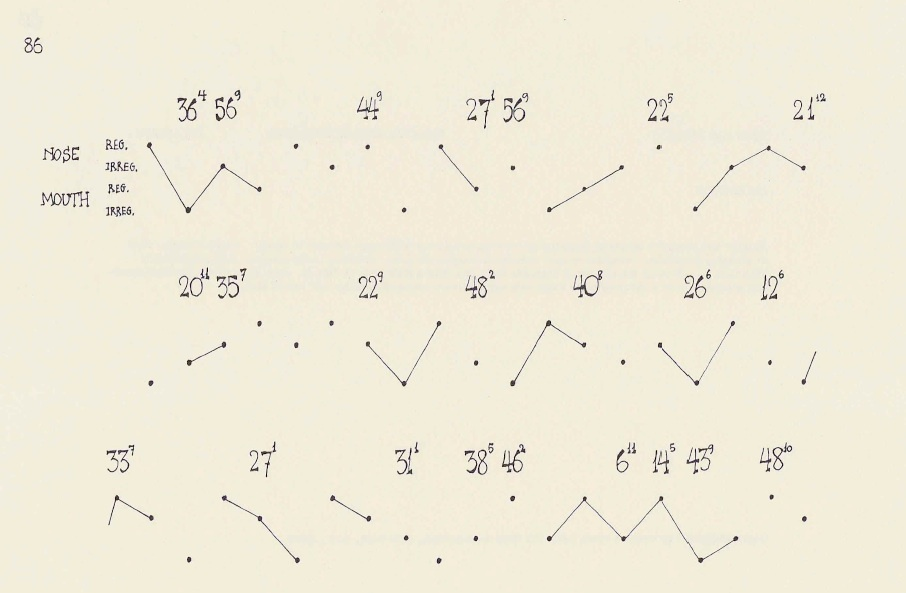

John Cage’s Solo for Voice, no. 22

(From [//////// Experimental Music Notation Resources](https://llllllll.co/t/experimental-music-notation-resources/149/102).)

[(or a wilder but less-known example)](https://llllllll.co/t/experimental-music-notation-resources/149/186)

[figure not shown]

Goyescas by Enrique Granados

(Sample from [LilyPond](https://lilypond.org/examples.html).)

### ERD Entity

Entities are descriptions of tables. Let’s say we’re making a database; we are going to put people into the database, and we need a contact email for them. We are going to call our table “person”, and when populated, it is going to end up looking like this:

```sql
 id |     name     |            email
----+--------------+-----------------------------
  1 | Hamid Brown  | hamidb@outlook.com
  2 | Ha Li        | hali@gmail.com
```

The smallest step in design is to start with “we are going to put people in our database…. A generic example of one of those will be an entity called ‘person’”.

### ERD Entity Attributes

For each row representing a person that we’re going to put in our “person” table, there is certain information we need to know. Our requirements are that we have a contact email. And we probably want to know the person’s name.

Each category of information we want to attach to our “person” is called an “attribute.” Each attribute adds to our knowledge about an entity.

Again working backwards from the table, what we will want for every person is:

```
person: id |  name  |  email
```

(This is just the column headers from the table.)

#### Attribute annotations

As the design gets more detailed and starts to approach the physical layout of the database, attributes may be annotated to indicate:

- what kind of datatype they should be
- if they are a key or part of a key (keys are next)
- if they help implement a relation (relations are later)

## Choosing Attributes

Attributes should differentiate.

The “Attributes” are usually not “build instructions” or a “has-a” list. Every customer is carbon-based, that is not an attribute a database needs to store separately for every person.

When looking at attributes, you are looking for things you need to differentiate, or to track. What is special about the entity?

## Summary

- Design is about the shape of tables, not any individual row
- the ERD (Entity-Relationship Diagram) is a tool database developers use
- an “Entity” in design represents any row in a table
- an “Attribute” in design represents a cloumn in a table

Things to remember about entities:

- they are abstract
- they are part of the design
- they are variables; placeholders

Data gets stored in tables, and tables get built after design is done.